# First Notebook

This first activity will use basic python to load and visualize data. We will:

- Load two datasets
- Perform any necessary data cleaning
- Reshape/Resample/Merge as needed
- Calculate basic descriptives
- Plot the data

The data is available in the `raw` folder.

*Make sure the folder is in the same directory as this notebook.*

This Notebook has **parts** of the code you need to to the tasks above. Follow the notes to complete or write the pieces of code you may need to finish.

```python
# Verify this line runs correctly.
# Otherwise, go to s1_env_check.ipynb

import pandas as pd  # import the pandas library and give it the alias "pd"
```

Load the GDP data

```python
df_gdp = pd.read_csv('../raw/gdp.csv',   # read a CSV file into a DataFrame; path is relative to this notebook
                     index_col='date',   # use the 'date' column as the row index instead of 0, 1, 2, ...
                     parse_dates=True)   # convert the index to datetime objects automatically

# Observe the data
df_gdp.tail(5)  # show the last 5 rows of the DataFrame
```

| date | gdp |
| --- | --- |
| 2024-12-01 | 431334 |
| 2025-03-01 | 436021 |
| 2025-06-01 | 437133 |
| 2025-09-01 | 438665 |
| 2025-12-01 | 406765 |

**COMPLETE.**

Load the stock data.

```python
# YOUR CODE HERE: call pd.read_csv(...) with the stock file path, index_col='date', parse_dates=True
df_stock = pd.read_csv('../raw/sp500.csv', index_col='date', parse_dates=True)

df_stock.tail(5)  # show the last 5 rows to verify the data loaded correctly
```

| date | sp500 |
| --- | --- |
| 2025-12-01 | 6853.025455 |
| 2026-01-01 | 6929.122000 |
| 2026-02-01 | 6893.806316 |
| 2026-03-01 | 6654.419091 |
| 2026-04-01 | 6908.205294 |

Open NTL data

```python
df_ntl = pd.read_csv('../raw/data_ntl_shape.csv',  # read the nighttime lights CSV file
                     index_col='date',          # use the 'date' column as the row index
                     parse_dates=True)          # parse dates so Python recognizes them as dates

df_ntl.head(10)  # show the first 10 rows (.tail shows last; .head shows first)
```

| date | ntl_mean | ntl_sum |
| --- | --- | --- |
| 2012-01-19 | 1.272979 | 68866.872397 |
| 2012-01-20 | 1.424077 | 77041.130328 |
| 2012-01-21 | 2.092794 | 113218.056544 |
| 2012-01-22 | 2.362034 | 127783.671390 |
| 2012-01-23 | 1.650252 | 89276.972640 |
| 2012-01-24 | 1.233973 | 66756.729011 |
| 2012-01-25 | 1.416948 | 76655.464130 |
| 2012-01-26 | 1.783512 | 96486.233810 |
| 2012-01-27 | 2.472152 | 133740.959514 |
| 2012-01-28 | 1.884260 | 101936.559525 |

Keep (select) only the average column

```python
# Double brackets [[ ]] select a subset of columns and return a DataFrame (single brackets return a Series)
# YOUR CODE HERE: put the column name you want to keep inside the inner brackets, e.g. df_ntl[['average']]
df_ntl = df_ntl[['ntl_mean']]
df_ntl.head(5)
```

| date | ntl_mean |
| --- | --- |
| 2012-01-19 | 1.272979 |
| 2012-01-20 | 1.424077 |
| 2012-01-21 | 2.092794 |
| 2012-01-22 | 2.362034 |
| 2012-01-23 | 1.650252 |

Let's start by visualizing

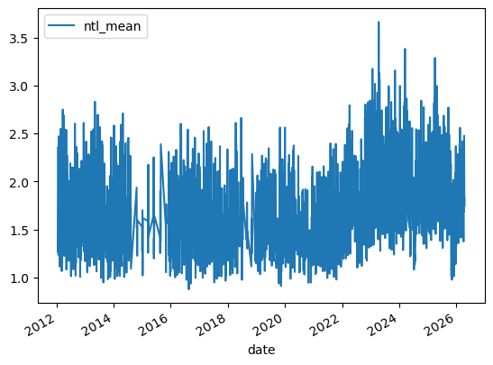

```python
# YOUR CODE HERE: call .plot() on df_ntl to visualize the series.
df_ntl.plot()
```

Notice the data has many missing values

the reason is mixed frequency.

Resample the data into quarterly frequency.

**COMPLETE**: **QS** standds for Quarter Start. **QE** for Quarter End.

```python
# YOUR CODE HERE: pass a frequency string inside resample(), e.g. resample('QS') for Quarter Start
# .mean() then averages all monthly values that fall within each quarter
df_ntl = df_ntl.resample('QS').mean()
df_ntl.tail(10)
```

| date | ntl_mean |
| --- | --- |
| 2024-01-01 | 1.866945 |
| 2024-04-01 | 1.883133 |
| 2024-07-01 | 1.758757 |
| 2024-10-01 | 1.852094 |
| 2025-01-01 | 1.898161 |
| 2025-04-01 | 2.087190 |
| 2025-07-01 | 1.948137 |
| 2025-10-01 | 1.629562 |
| 2026-01-01 | 1.765616 |
| 2026-04-01 | 1.777356 |

```python
# dropna removes rows with missing values (NaN)
# how='all' means: only drop a row if ALL its columns are NaN (keeps rows missing just one value)
# axis=0 means operate on rows (axis=1 would operate on columns)
df_ntl = df_ntl.dropna(how='all', axis=0)
df_ntl.tail(10)
```

| date | ntl_mean |
| --- | --- |
| 2024-01-01 | 1.866945 |
| 2024-04-01 | 1.883133 |
| 2024-07-01 | 1.758757 |
| 2024-10-01 | 1.852094 |
| 2025-01-01 | 1.898161 |
| 2025-04-01 | 2.087190 |
| 2025-07-01 | 1.948137 |
| 2025-10-01 | 1.629562 |
| 2026-01-01 | 1.765616 |
| 2026-04-01 | 1.777356 |

This is just a column but if there were more, there could still be missing values because we used the `how='all'` parameter. Let's use `how='any'` instead.

**COMPLETE**

```python
# dropna() with no arguments defaults to how='any': drops a row if ANY column has NaN
df_ntl = df_ntl.dropna()
df_ntl.tail(5)
```

| date | ntl_mean |
| --- | --- |
| 2025-04-01 | 2.087190 |
| 2025-07-01 | 1.948137 |
| 2025-10-01 | 1.629562 |
| 2026-01-01 | 1.765616 |
| 2026-04-01 | 1.777356 |

Descriptive statistics here

```python
df_ntl.describe()  # returns count, mean, std, min, quartiles, and max for each numeric column
```

|  | ntl_mean |
| --- | --- |
| count | 58.000000 |
| mean | 1.635601 |
| std | 0.166790 |
| min | 1.365451 |
| 25% | 1.516362 |
| 50% | 1.593312 |
| 75% | 1.743566 |
| max | 2.087190 |

**COMPLETE**: Can we plot?

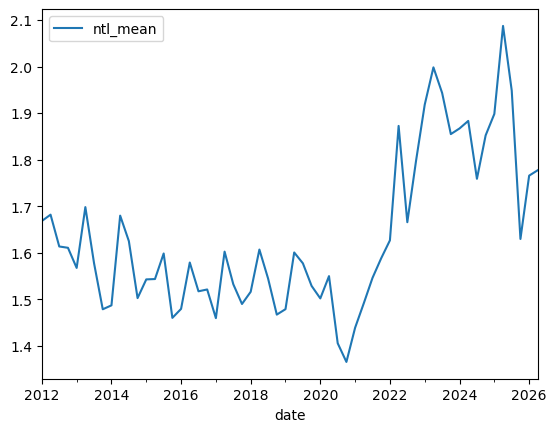

```python
# YOUR CODE HERE: call .plot() on df_ntl to draw a line chart, e.g. df_ntl.plot()
df_ntl.plot()
```

# Merge data

We have 3 series

```
(<Axes: xlabel='date'>, <Axes: xlabel='date'>, <Axes: xlabel='date'>)
```

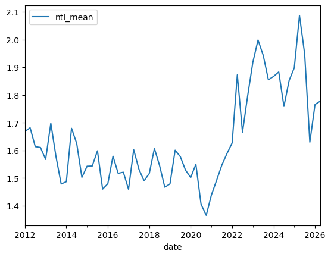

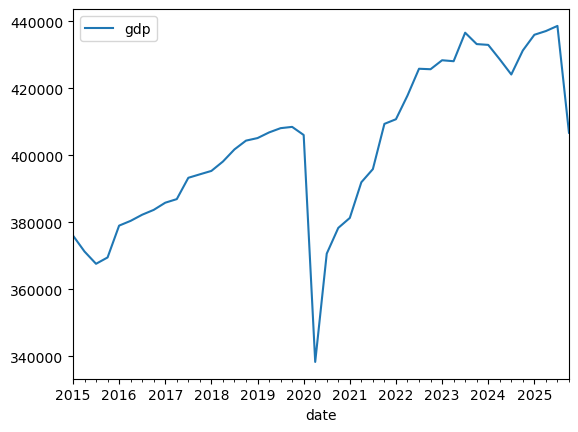

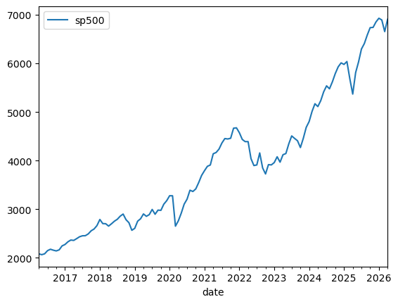

```python
# Calling .plot() on each DataFrame opens a separate chart for each series
# Expressions separated by commas inside a cell return a tuple of results — each plot displays inline
df_ntl.plot(), df_gdp.plot(), df_stock.plot()
```

Resample stock data into quarters

```python
df_stock = df_stock.resample('QS').mean()  # group daily/monthly data into quarters (Quarter Start) and average
df_stock.tail(10)
```

| date | sp500 |
| --- | --- |
| 2024-01-01 | 4995.675143 |
| 2024-04-01 | 5254.286236 |
| 2024-07-01 | 5545.826530 |
| 2024-10-01 | 5911.048045 |
| 2025-01-01 | 5900.729611 |
| 2025-04-01 | 5736.788913 |
| 2025-07-01 | 6429.821934 |
| 2025-10-01 | 6776.534328 |
| 2026-01-01 | 6825.782469 |
| 2026-04-01 | 6908.205294 |

Now merge, but...

```python
# .merge() joins two DataFrames — like a SQL JOIN
# left_index=True, right_index=True means use the row index (date) as the join key on both sides
df_merge = df_ntl.merge(df_gdp, left_index=True, right_index=True)
df_merge = df_merge.merge(df_stock, left_index=True, right_index=True)  # chain a second merge onto the result
df_merge
```

|  | ntl_mean | gdp | sp500 |
| --- | --- | --- | --- |
| date |  |  |  |

It's not working. This is a common problem. The date indexes do not align. Look at GDP again:

```python
df_gdp.tail(5)
```

| date | gdp |
| --- | --- |
| 2024-12-01 | 431334 |
| 2025-03-01 | 436021 |
| 2025-06-01 | 437133 |
| 2025-09-01 | 438665 |
| 2025-12-01 | 406765 |

There are several fixes. Like resampling GDP to QS. In this case, let's apply some date functions:

```python
# pd.DateOffset shifts dates by a fixed amount; here we add 2 months to move QS (Jan/Apr/Jul/Oct) to QE (Mar/Jun/Sep/Dec)
# Reassigning .index replaces the entire index of the DataFrame in place
df_ntl.index = df_ntl.index + pd.DateOffset(months=2)
df_stock.index = df_stock.index + pd.DateOffset(months=2)
df_stock.tail(5)
```

| date | sp500 |
| --- | --- |
| 2025-06-01 | 5736.788913 |
| 2025-09-01 | 6429.821934 |
| 2025-12-01 | 6776.534328 |
| 2026-03-01 | 6825.782469 |
| 2026-06-01 | 6908.205294 |

```python
# Now that the date indexes match, the merge should produce non-empty rows
df_merge = df_ntl.merge(df_gdp, left_index=True, right_index=True)
df_merge = df_merge.merge(df_stock, left_index=True, right_index=True)
df_merge
```

| date | ntl_mean | gdp | sp500 |
| --- | --- | --- | --- |
| 2016-06-01 | 1.578983 | 380452 | 2077.530772 |
| 2016-09-01 | 1.517159 | 382285 | 2161.358375 |
| 2016-12-01 | 1.521077 | 383727 | 2184.878571 |
| 2017-03-01 | 1.459510 | 385870 | 2323.949567 |
| 2017-06-01 | 1.602375 | 386945 | 2396.213613 |
| 2017-09-01 | 1.532358 | 393308 | 2467.722181 |
| 2017-12-01 | 1.489896 | 394347 | 2604.981162 |
| 2018-03-01 | 1.516096 | 395365 | 2732.577628 |
| 2018-06-01 | 1.606802 | 398167 | 2703.157244 |
| 2018-09-01 | 1.544570 | 401787 | 2850.988098 |
| 2018-12-01 | 1.467081 | 404410 | 2692.000558 |
| 2019-03-01 | 1.478753 | 405172 | 2722.079340 |
| 2019-06-01 | 1.600551 | 406856 | 2882.890636 |
| 2019-09-01 | 1.577211 | 408132 | 2958.589273 |
| 2019-12-01 | 1.528719 | 408515 | 3086.443080 |
| 2020-03-01 | 1.501864 | 406098 | 3069.303568 |
| 2020-06-01 | 1.549749 | 338323 | 2928.750382 |
| 2020-09-01 | 1.405559 | 370658 | 3321.615253 |
| 2020-12-01 | 1.365451 | 378343 | 3554.334621 |
| 2021-03-01 | 1.438901 | 381323 | 3862.562929 |
| 2021-06-01 | 1.491602 | 391979 | 4182.505078 |
| 2021-09-01 | 1.545995 | 395905 | 4421.154185 |
| 2021-12-01 | 1.588242 | 409411 | 4600.955512 |
| 2022-03-01 | 1.626595 | 410800 | 4467.020414 |
| 2022-06-01 | 1.872416 | 417863 | 4110.200889 |
| 2022-09-01 | 1.665564 | 425874 | 3973.604340 |
| 2022-12-01 | 1.797160 | 425732 | 3851.973492 |
| 2023-03-01 | 1.918031 | 428412 | 4002.966789 |
| 2023-06-01 | 1.998197 | 428126 | 4204.337802 |
| 2023-09-01 | 1.943247 | 436638 | 4458.176399 |
| 2023-12-01 | 1.854829 | 433240 | 4471.505247 |
| 2024-03-01 | 1.866945 | 433003 | 4995.675143 |
| 2024-06-01 | 1.883133 | 428684 | 5254.286236 |
| 2024-09-01 | 1.758757 | 424159 | 5545.826530 |
| 2024-12-01 | 1.852094 | 431334 | 5911.048045 |
| 2025-03-01 | 1.898161 | 436021 | 5900.729611 |
| 2025-06-01 | 2.087190 | 437133 | 5736.788913 |
| 2025-09-01 | 1.948137 | 438665 | 6429.821934 |
| 2025-12-01 | 1.629562 | 406765 | 6776.534328 |

Plot

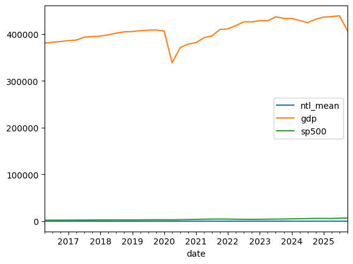

```python
df_merge.plot()
```

Yes, but we may want to make the comparison meaningful. Let's normalize both series to the QoQ rate of change.

```python
df_change = df_merge.pct_change()  # compute period-over-period percentage change: (current - previous) / previous
df_change.head(5)  # first row will be NaN because there is no previous value to compare against
```

| date | ntl_mean | gdp | sp500 |
| --- | --- | --- | --- |
| 2016-06-01 | NaN | NaN | NaN |
| 2016-09-01 | -0.039154 | 0.004818 | 0.040350 |
| 2016-12-01 | 0.002582 | 0.003772 | 0.010882 |
| 2017-03-01 | -0.040476 | 0.005585 | 0.063652 |
| 2017-06-01 | 0.097885 | 0.002786 | 0.031095 |

Plot

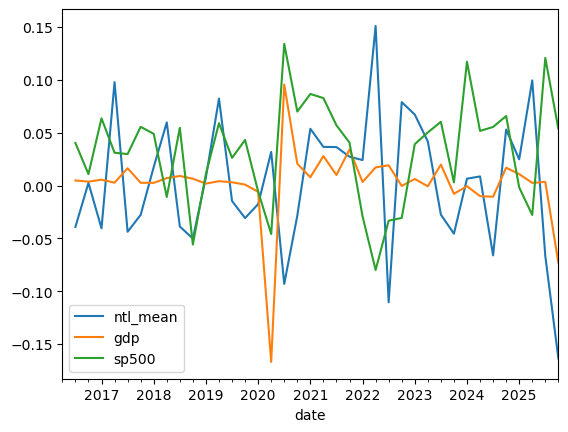

```python
df_change.plot()
```